# Lab 1

# a) Variables and Types

## 1:

There is no difference

## 2:

logical, integer, real, complex, string,

## 3:

```r
4 + T
```

```
[1] 5
```

```r
4 + "false"
```

```
Error in 4 + "false" : non-numeric argument to binary operator
```

## 4:

sum is not int the boolean format because ‘+’ is an operation for numeric data types.

```r
sum <- T + F
sum
```

```
[1] 1
```

```r
typeof(sum)
```

```
[1] "integer"
```

```r
sum <- as.logical(sum)
typeof(sum)
```

```
[1] "logical"
```

```r
sum
```

```
[1] TRUE
```

# b) Data structures

## 5:

Vector, list, matrix, data frame, factors

# c) Vectors

## 6:

```r
vec <- c(1, 2, 3)
vec
```

```
[1] 1 2 3
```

## 7:

We can’t put variables of different types in a vector, since a vector is a random variable, so all variables in a vector must have the same type.

## 8:

```r
feature_1 <- c(50 : 250)
feature_1
```

```
  [1]  50  51  52  53  54  55  56  57  58  59  60  61  62  63  64  65  66  67  68  69  70  71  72  73  74  75  76  77
 [29]  78  79  80  81  82  83  84  85  86  87  88  89  90  91  92  93  94  95  96  97  98  99 100 101 102 103 104 105
 [57] 106 107 108 109 110 111 112 113 114 115 116 117 118 119 120 121 122 123 124 125 126 127 128 129 130 131 132 133
 [85] 134 135 136 137 138 139 140 141 142 143 144 145 146 147 148 149 150 151 152 153 154 155 156 157 158 159 160 161
[113] 162 163 164 165 166 167 168 169 170 171 172 173 174 175 176 177 178 179 180 181 182 183 184 185 186 187 188 189
[141] 190 191 192 193 194 195 196 197 198 199 200 201 202 203 204 205 206 207 208 209 210 211 212 213 214 215 216 217
[169] 218 219 220 221 222 223 224 225 226 227 228 229 230 231 232 233 234 235 236 237 238 239 240 241 242 243 244 245
[197] 246 247 248 249 250
```

## 9:

```r
length(feature_1)
```

```
[1] 201
```

## 10:

```r
mean(feature_1)
```

```
[1] 150
```

```r
var(feature_1)
```

```
[1] 3383.5
```

```r
sd(feature_1)
```

```
[1] 58.16786
```

```r
median(feature_1)
```

```
[1] 150
```

## 11:

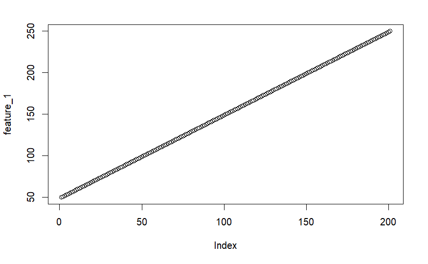

```r
plot(feature_1)
```

## 12:

```r
a <- feature_1[6 : 22]
a
```

```
 [1] 55 56 57 58 59 60 61 62 63 64 65 66 67 68 69 70 71
```

## 13:

```r
b <- feature_1[c(6, 13, 21, 22, 43)]
b
```

```
[1] 55 62 70 71 92
```

## 14:

```r
c <- c(a, b)
c
```

```
 [1] 55 56 57 58 59 60 61 62 63 64 65 66 67 68 69 70 71 55 62 70 71 92
```

## 15:

```r
find_a <- function(str){
  return (grepl("a", str))
}

str <- c("joey", "phoebe", "monica", "chandler", "ross", "rachel")
sum(as.integer(lapply(str, find_a)))
```

```
[1] 3
```

# d) Factors

## 16:

Factor in R is **a variable used to categorize and store the data, having a limited number of different values**.

Factors have limited number of different values, while vectors don’t have any limitation.

```r
directions <- c("West", "East", "East", "North", "West", "West")
feature_2 <- factor (directions)
```

## 17:

It isn’t possible, because ‘South’ isn’t one of feature_2’s levels.

## 18:

```r
levels(feature_2) <- c(levels(feature_2), "South")
feature_2
```

```
[1] West  East  East  North West  West
Levels: East North West South
```

## 19:

There is nothing important to report, everything works well.

```r
feature_2[1] <- "South"
feature_2
```

```
[1] South East  East  North West  West
Levels: East North West South
```

# e) Missing values

## 20:

NA

## 21:

```r
feature_1[1] <- NA
feature_1
```

```
  [1]  NA  51  52  53  54  55  56  57  58  59  60  61  62  63  64  65  66  67  68  69  70  71  72  73  74  75  76  77
 [29]  78  79  80  81  82  83  84  85  86  87  88  89  90  91  92  93  94  95  96  97  98  99 100 101 102 103 104 105
 [57] 106 107 108 109 110 111 112 113 114 115 116 117 118 119 120 121 122 123 124 125 126 127 128 129 130 131 132 133
 [85] 134 135 136 137 138 139 140 141 142 143 144 145 146 147 148 149 150 151 152 153 154 155 156 157 158 159 160 161
[113] 162 163 164 165 166 167 168 169 170 171 172 173 174 175 176 177 178 179 180 181 182 183 184 185 186 187 188 189
[141] 190 191 192 193 194 195 196 197 198 199 200 201 202 203 204 205 206 207 208 209 210 211 212 213 214 215 216 217
[169] 218 219 220 221 222 223 224 225 226 227 228 229 230 231 232 233 234 235 236 237 238 239 240 241 242 243 244 245
[197] 246 247 248 249 250
```

## 22:

We can set “na.rm” argument, true in mean() function to resolve this problem.

```r
mean(feature_1, na.rm = T)
```

```
[1] 150.5
```

## 23:

```r
feature_1[43] <- NA
which(is.na(feature_1))
```

```
[1]  1 43
```

## 24:

**NULL represents the null object in R**. NULL is used mainly to represent the lists with zero length, and is often returned by expressions and functions whose value is undefined.

# f) Lists

## 25:

List is a list of variables which types could be different.

## 26:

list [x] will return a list which only contains the x_th element of list, while list [[x]] will return x_th element of list, it self.

```r
lst <- list(4, 5, 6, list(7, 8, "xyz"))
```

# g) Naming

```r
named_list <- list(a = 1, b = 2, c = 3, d = c(4, 5, 6, 7))
```

## 27:

First one returns a list contains 2, while other ones returns 2 itself.

it is a syntax sugar for [[]] because they both do the same thing.

```r
named_list["b"]
```

[output not shown]

```r
named_list[["b"]]
```

[output not shown]

```r
named_list$b
```

[output not shown]

# h) Data Frames

## 28:

```r
ncol(Orange)
```

[output not shown]

## 29:

```r
nrow(Orange)
```

[output not shown]

## 30:

```r
f3 <- Orange$circumference
f3_tmp <- Orange[[3]]
```

## 31:

f3 is a vector.

Due to the dipersion of circumference feature, this data set had been chosen randomly.

```r
table(f3)
```

[output not shown]

## 32:

Tree feature is catagorical

```r
str(Orange)
```

[output not shown]

## 33:

```r
s29 <- Orange[29, ]
s29
```

[output not shown]

## 34:

It is a data frame with one row.

## 35:

```r
Orange[c(Orange$Tree == 3), ]
```

[output not shown]

## 36:

```r
tmp <- Orange[1 : 10, c("Tree", "age")]
tmp
```

[output not shown]

## 37:

```r
median(Orange$age)
```

[output not shown]

# i) Export and Import

## 38:

```r
df_1 <- tail(Orange, n = 15)
```

## 39:

```r
write.csv(df_1, "df_1.csv", row.names = F)
```

## 40:

```r
df_2 <- read.csv("df_1.csv")
df_2
```

[output not shown]